# 2. Matplotlib基礎_Q slides

## 練習

- 請於同一圖表中繪製sin圖形及cos圖形
- sin請用橘色表示、cos請用深藍色表示
- x座標僅標示0、90、180、270...810
- x軸原點請對齊圖形最左邊
- 繪製圖例

## 練習

- 請於同一圖表中繪製sin圖形、2倍sin圖形及0.5倍sin圖形，並觀察其結果
- 繪製圖例

## 水平線與垂直線

```
plt.axhline(y=0, xmin=0, xmax=0, linestyle='style', linewidth='width', color='color')  # 水平線

plt.axvline(x=0, ymin=0, ymax=0, linestyle='style', linewidth='width', color='color')  # 垂直線
```

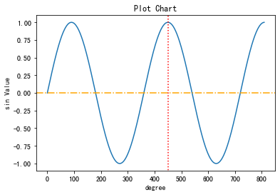

```python
## 範例

import numpy as np
import matplotlib.pyplot as plt

plt.rcParams['axes.unicode_minus']=False
xcoor = [i for i in range(810)]
ycoor = [np.sin(np.deg2rad(i)) for i in range(810)]
plt.plot(xcoor, ycoor)
plt.axhline(color='orange', linestyle='-.')
plt.axvline(x=450, ymin=-1, ymax=1, color='red', linestyle=':')
plt.axis()
plt.title('Plot Chart')
plt.xlabel('degree')
plt.ylabel('sin Value')
plt.show()
```

## 區間填滿

```
fill_between(x, y1, y2, color, alpha)   #填滿所有x軸的y1和y2區間，顏色為color，透明度alpha
```

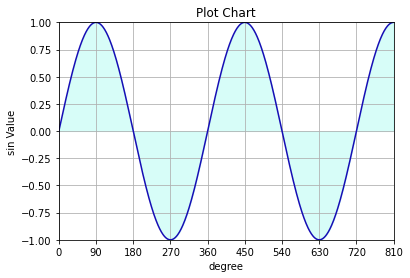

```python
#範例

import numpy as np
import matplotlib.pyplot as plt

xcoor = [i for i in range(810)]
ycoor = [np.sin(np.deg2rad(i)) for i in range(810)]
plt.plot(xcoor, ycoor, c='#170db5')
plt.title('Plot Chart')
plt.xlabel('degree')
plt.ylabel('sin Value')
plt.axis([0, 810, -1, 1])
plt.xticks([0, 90, 180, 270, 360, 450, 540, 630, 720, 810])
plt.grid()
plt.fill_between(xcoor, 0, ycoor, color='#7bf9ea', alpha=0.3)
plt.show()
```

## 練習

- 承上題練習題
  - 請於同一圖表中繪製sin圖形及cos圖形
  - sin請用橘色表示、cos請用深藍色表示
  - x座標僅標示0、90、180、270...810
  - x軸原點請對齊圖形最左邊
  - 繪製圖例
- 請將sin正值的部分填滿淡橘色
- 請將cos負值的部分填滿淡藍色

## 設定中文字

```python
## 查看設定檔路徑

import matplotlib
print(matplotlib.matplotlib_fname())
```

```
/Library/Frameworks/Python.framework/Versions/3.7/lib/python3.7/site-packages/matplotlib/mpl-data/matplotlibrc
```

## 字體下載

下載[SimHei.ttf](http://www.font5.com.cn/font_download.php?id=151&part=1237887120)字體

## 置檔、變更設定及清除快取

- 置檔
  - 將抓下來的tff檔案放入剛剛查詢到設定檔的相對路徑
    - 如：`/Library/Frameworks/Python.framework/Versions/3.7/lib/python3.7/site-packages/matplotlib/mpl-data/fonts/tff`

## 變更設定

- 變更設定
  - 進入查詢到的設定檔加入新字體名稱：於`#font.serif`與`#font.sans-serif後`加入名稱如下

    ```
         部分檔案內容如下：
          #font.style:   normal
          #font.variant: normal
          #font.weight:  normal
          #font.stretch: normal
          #font.size:    10.0

          #font.serif:      simhei, DejaVu Serif, Bitstream Vera Serif, Computer Modern Roman, New Century Schoolbook, Century Schoolbook L, Utopia, ITC Bookman, Bookman, Nimbus Roman No9 L, Times New Roman, Times, Palatino, Charter, serif
          #font.sans-serif: simhei, DejaVu Sans, Bitstream Vera Sans, Computer Modern Sans Serif, Lucida Grande, Verdana, Geneva, Lucid, Arial, Helvetica, Avant Garde, sans-serif
          #font.cursive:    Apple Chancery, Textile, Zapf Chancery, Sand, Script MT, Felipa, Comic Neue, Comic Sans MS, cursive
          #font.fantasy:    Chicago, Charcoal, Impact, Western, Humor Sans, xkcd, fantasy
          #font.monospace:  DejaVu Sans Mono, Bitstream Vera Sans Mono, Computer Modern Typewriter, Andale Mono, Nimbus Mono L, Courier New, Courier, Fixed, Terminal, monospace
    ```

## 清除快取

- 清除快取
  - 刪除以下路徑的fontlist檔案

    ```
      MAC：/Users/使用者名稱/.matplotlib
      Windows：C:\Users\使用者名稱\.matplotlib
    ```

## 程式碼加入中文字設定

```
import matplotlib as plt

plt.rcParams['font.sans-serif']=['SimHei'] #用來正常顯示中文標籤
plt.rcParams['axes.unicode_minus']=False #用來正常顯示負號
```

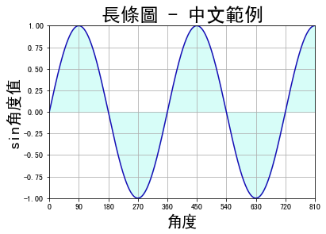

```python
#範例

import numpy as np
import matplotlib.pyplot as plt

plt.rcParams['font.sans-serif']=['SimHei']
plt.rcParams['axes.unicode_minus']=False

xcoor = [i for i in range(810)]
ycoor = [np.sin(np.deg2rad(i)) for i in range(810)]
plt.plot(xcoor, ycoor, c='#170db5')
plt.title('長條圖 - 中文範例', fontsize=24)
plt.xlabel('角度', fontsize=20)
plt.ylabel('sin角度值', fontsize=20)
plt.axis([0, 810, -1, 1])
plt.xticks([0, 90, 180, 270, 360, 450, 540, 630, 720, 810])
plt.grid()
plt.fill_between(xcoor, 0, ycoor, color='#7bf9ea', alpha=0.3)
plt.show()
```

## 練習

- 承上題練習題
- 請更改圖中的title名稱，將其改為中文字體